# ABDA (week 4) Basics of MCMC: Exercises

Florian Pätzold, 977687

05/14/2020

# Instructions

- If you need help, take a look at the suggested readings in the lecture, make use of the Forum, make use of the Forum, and also make use of the Forum.
- Use the file `04-exercises.Rmd`, solve the exercises marked as homework, and save the file with your student number and name.
- ‘Knit’ the document to produce a HTML file.
- Please do not suppress the code in the HTML-Output!
- Create a ZIP archive called “MATRIKELNR_Lastname_Firstname_ABDA_Week4.zip” containing:
  - an R Markdown file “MATRIKELNR_Lastname_Firstname_ABDA_Week4.Rmd”
  - a knitted HTML document “MATRIKELNR_Lastname_Firstname_ABDA_Week4.html”
- Upload the ZIP archive on Stud.IP in the homework folder before the deadline. You may upload as many times as you like before the deadline, only your final submission will count.

# Preliminaries

To use the latest additions to the course package, make sure to update once with manually executing the command:

```r
# devtools::install_github("michael-franke/aida-package")
```

We are going to set a seed, so that results from (pseudo-)random executions are repeatable.

```r
set.seed(1969)
```

# Motivation and learning goals

The main **learning goals** of this week’s practical part are:

- get familiar with the Metropolis Hastings algorithm
- see the importance of fine-tuning parameter for MH (in particular: the proposal function)
- test samples for their representativeness (diagnostics)
  - calculate and interpret the $\hat{R}$ statistic
  - produce and interpret traceplots
  - calculate and understand efficient sample size
- understand how an “intercept-only” regression model estimates the parameters of a Gaussian model

# Exercise 1 [SELF-PRACTICE]: A hand-coded MH-sampler for a single normal model

We are going to, again, try to estimate the joint posterior of the mean $\mu$ and standard deviation $\sigma$ that could have generated the following fictitious (flower) data:

```r
# flower height data (as before)
heights_A <- c(6.94, 11.77, 8.97, 12.2, 8.48,
               9.29, 13.03, 13.58, 7.63, 11.47,
               10.24, 8.99, 8.29, 10.01, 9.47,
               9.92, 6.83, 11.6, 10.29, 10.7,
               11, 8.68, 11.71, 10.09, 9.7)
```

We assume that priors on $\mu$ and $\sigma$ are independent, and that both are sampled from a wide Gaussian (truncated at zero in the case of $\sigma$, which cannot be non-positive):

$$\begin{align*}
\sigma & \sim \text{Trunc-Normal}(0, 50, 0) \\
\mu & \sim \text{Normal}(0, 50) \\
\end{align*}$$

To implement the MH sampler, we are first going to define the “target function”, i.e., the description of the distribution which we would like to approximate by sampling. In the case of a Bayesian posterior, this is the RHS of Bayes rule using non-normalized weights:

$$P(\mu, \sigma \mid D) \propto P(\mu, \sigma) \times P(D \mid \mu, \sigma)$$
Since the values of $P(\mu, \sigma) \times P(D \mid \mu, \sigma)$ can become very small, especially for cases with many data points, the function below returns the logarithm of the non-normalized posteriors, because logarithms of very small numbers are negatives of very large numbers and these are more precisely represented by modern computers:

```r
# target function to approximate:
#   log of non-normalized posterior: prior times likelihood
target_f <- function(mu, sigma){
  # sigma cannot be negative
  if (sigma <=0){
    return(-Inf)
  }
  # prior over mean mu: normal distribution
  prior_mu    <- dnorm(mu, mean = 0, sd = 50, log = T)
  # prior over sigma: (truncated) normal distribution
  prior_sigma <- dnorm(sigma, mean = 0, sd = 50, log = T)
  likelihood  <- sum(dnorm(heights_A, mean = mu, sd = sigma, log = T))
  return(prior_mu + prior_sigma + likelihood)
}
```

Here is an instance of a Metropolis Hastings sampler. The most important parts to understand here are:

- the initialization of parameters for the jumping, which is here informed by the data to start in reasonable vicinity to the “typical set”
- the sampling of the proposal step, which is asymmetric for $\sigma$, which is why we use MH in the first place, following the description in Chapter 13.8 of Lambert’s book
- the calculation of the acceptance probability, correcting for the asymmetry in the proposal function

What is less important theoretically, but useful to note for technical reasons is that the output is presented as a so-called `mcmc.list`, which is a special object defined in the `coda` package to deal with results from MCMC samplers.

```r
MH_Gaussian <- function(iterations = 50, chains = 2, warmup = 0){
  # prepare 'container' to store the output
  out <- array(0, dim = c(chains, iterations - warmup, 2))
  dimnames(out) <- list("chain" = 1:chains,
                       "iteration" = 1:(iterations-warmup),
                       "variable" = c("mu", "sigma"))
  # iterate over chains
  for (c in 1:chains){
    # sample initial parameters at random using the data to guide us to the "typical set"
    mu    <- rnorm(1, mean = 10, sd = 7)
    sigma <- abs(rnorm(1, mean = 0, sd = 10))
    # iterate MCMC steps
    for (i in 1:iterations){
      # generate proposal for next parameter pair
      mu_next    <- rnorm(1, mean = mu, sd = 1)
      d <- 1
      sigma_next <- rlnorm(1, mean = log(sigma) - 0.5*d^2, sdlog = d)
      # calculate the accept rate (correcting for asymetric proposals for sigma)
      accept_prob <- min(
        exp(
          target_f(mu_next, sigma_next) -
            target_f(mu, sigma) +
            dlnorm(sigma, mean = log(sigma_next) - 0.5*d^2, sdlog = d, log = T) -
            dlnorm(sigma_next, mean = log(sigma) - 0.5*d^2, sdlog = d, log = T)
        ),
        1
      )
      # test the accept rate
      if (rbernoulli(1, p = accept_prob)) {
        mu    <- mu_next
        sigma <- sigma_next
      }
      # record sample (only after warmup)
      if (i >= warmup){
        out[c,i-warmup,1] <- mu
        out[c,i-warmup,2] <- sigma
      }
    }
  }
  # return samples as an 'mcmc.list' object (from the 'coda' package)
  return(coda::mcmc.list(map(1:chains, function(c) coda::mcmc(out[c,,]))))
}
```

Let’s now take 20,000 samples from four chains each, discarding the initial 5000 from each chain, so that we end up with $4 \times 15,000 = 60,000$ samples.

```r
MH_samples_Gaussian <- MH_Gaussian(
  iterations = 20000,
  chains = 4,
  warmup = 5000
)
```

## Exercise 1a [SELF-PRACTICE]: Inspecting the output

Get familiar with the output we have just obtained. Use `head` and `summary` and try to understand what you see. If you want to know more about `mcmc.list` objects in general (though this is not going to be very relevant for this course) use `help('mcmc.list')`.

```r
head(MH_samples_Gaussian)
```

```
## [[1]]
## Markov Chain Monte Carlo (MCMC) output:
## Start = 1
## End = 7
## Thinning interval = 1
##          variable
## iteration       mu    sigma
##         1 10.36829 1.994577
##         2 10.36829 1.994577
##         3 10.36829 1.994577
##         4 10.36829 1.994577
##         5 10.36829 1.994577
##         6 10.36829 1.994577
##         7 10.36829 1.994577
##
## [[2]]
## Markov Chain Monte Carlo (MCMC) output:
## Start = 1
## End = 7
## Thinning interval = 1
##          variable
## iteration       mu    sigma
##         1 10.03551 1.719727
##         2 10.03551 1.719727
##         3 10.03551 1.719727
##         4 10.03551 1.719727
##         5 10.16476 1.868258
##         6 10.16476 1.868258
##         7 10.16476 1.868258
##
## [[3]]
## Markov Chain Monte Carlo (MCMC) output:
## Start = 1
## End = 7
## Thinning interval = 1
##          variable
## iteration       mu    sigma
##         1 9.155612 2.020933
##         2 9.155612 2.020933
##         3 9.155612 2.020933
##         4 9.432600 1.782443
##         5 9.432600 1.782443
##         6 9.432600 1.782443
##         7 9.432600 1.782443
##
## [[4]]
## Markov Chain Monte Carlo (MCMC) output:
## Start = 1
## End = 7
## Thinning interval = 1
##          variable
## iteration        mu    sigma
##         1 10.042312 1.965293
##         2 10.321057 1.316930
##         3 10.613995 2.696102
##         4 10.613995 2.696102
##         5  9.635914 1.921646
##         6  9.635914 1.921646
##         7  9.635914 1.921646
##
## attr(,"class")
## [1] "mcmc.list"
```

```r
print(summary(MH_samples_Gaussian), digits=6)
```

```
##
## Iterations = 1:15000
## Thinning interval = 1
## Number of chains = 4
## Sample size per chain = 15000
##
## 1. Empirical mean and standard deviation for each variable,
##    plus standard error of the mean:
##
##           Mean       SD   Naive SE Time-series SE
## mu    10.03619 0.377720 0.00154203     0.00737801
## sigma  1.85837 0.288995 0.00117982     0.00494222
##
## 2. Quantiles for each variable:
##
##          2.5%     25%      50%      75%    97.5%
## mu    9.30069 9.78429 10.04291 10.28423 10.78415
## sigma 1.39982 1.64518  1.81692  2.03009  2.52751
```

## Exercise 1b [SELF-PRACTICE]: Make a scatter plot of the samples

To work with samples stored as an `mcmc.list` in a tidyverse workflow, we can use the function `ggmcmc::ggs` from the `ggmcmc` package.

```r
MH_samples_Gaussian_tidy <- ggmcmc::ggs(MH_samples_Gaussian)
head(MH_samples_Gaussian_tidy)
```

```
## # A tibble: 6 x 4
##   Iteration Chain Parameter value
##       <int> <int> <fct>     <dbl>
## 1         1     1 mu         10.4
## 2         2     1 mu         10.4
## 3         3     1 mu         10.4
## 4         4     1 mu         10.4
## 5         5     1 mu         10.4
## 6         6     1 mu         10.4
```

Use `MH_samples_Gaussian_tidy` to produce a scatter plot with $\sigma$ on the $x$-axis and $\mu$ on the $y$-axis.

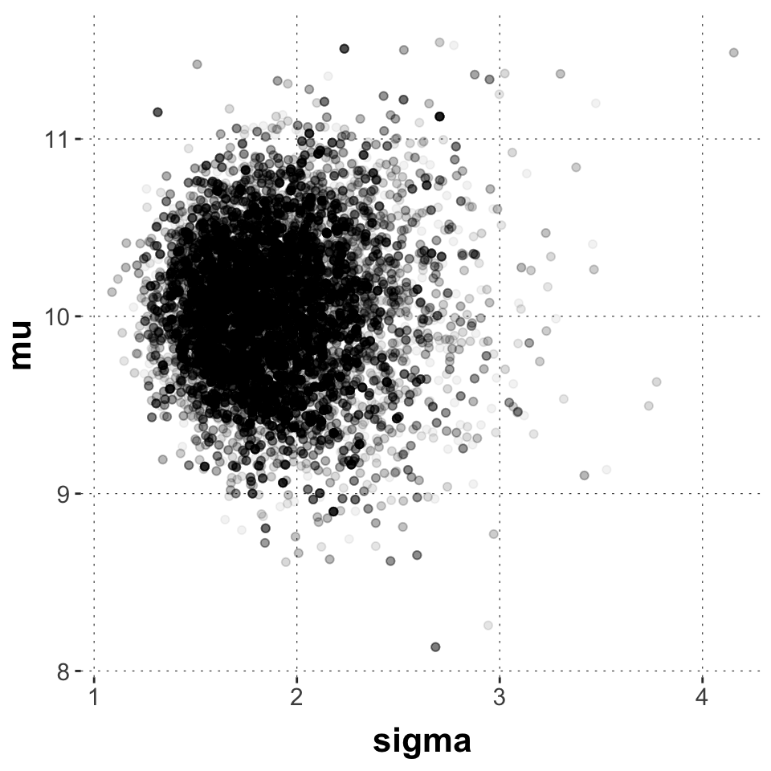

```r
MH_samples_Gaussian_tidy <-
  MH_samples_Gaussian_tidy %>%
  pivot_wider(names_from = Parameter, values_from = value)

MH_samples_Gaussian_tidy %>%
  ggplot(aes(x = sigma, y = mu)) +
  geom_point(alpha = 0.05) +
  theme_aida()
```

## Exercise 1c [SELF-PRACTICE]: More summary statistics and a comparison to previous results

Use the convenience function `summarize_sample_vector` to obtain a tibble of means and 95% credible intervals for each parameter (like we did in earlier weeks). Compare the results from the homebrew MH to the results from sampling with the non-informative standard prior we used before. Are there any major differences? Are you surprised that there are (none)?

```r
# convenience functions (from last week)
summarize_sample_vector <- function(samples, name = '') {
    tibble(
      Parameter = name,
      '|95%' = HDInterval::hdi(samples)[1],
      mean  = mean(samples),
      '95%|' = HDInterval::hdi(samples)[2]
    )
}
```

```r
rbind(
  summarize_sample_vector(samples = MH_samples_Gaussian_tidy$mu, name="mu"),
  summarize_sample_vector(samples = MH_samples_Gaussian_tidy$sigma, name="sigma")
)
```

```
## # A tibble: 2 x 4
##   Parameter `|95%`  mean `95%|`
##   <chr>      <dbl> <dbl>  <dbl>
## 1 mu          9.34 10.0   10.8
## 2 sigma       1.37  1.86   2.47
```

## Exercise 1d [SELF-PRACTICE]: Inspecting chain diagnostics

The `coda` package defines a number of useful functions for running MCMC diagnostics. But let’s first look at a traceplot for our samples, making use of the plotting facilities of the `bayesplot` package. Run the following command and try to evaluate whether this picture suggests convergence:

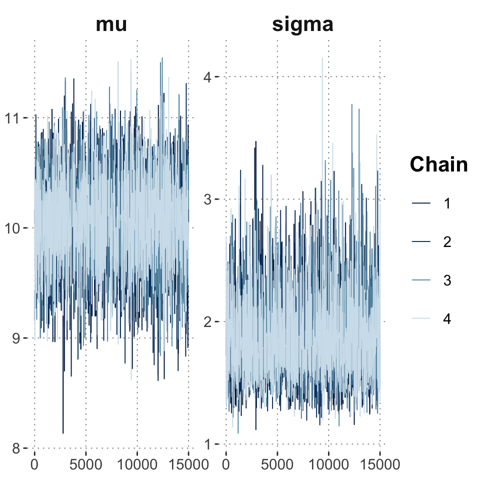

```r
bayesplot::mcmc_trace(MH_samples_Gaussian)
```

**Answer:** The picture suggests convergence, as the chains are fairly intertwined, “hangling” around about the same typical set.

If we want to have a numerical measure of chain convergence, we can produce the $\hat{R}$ statistic for each parameter like so:

```r
coda::gelman.diag(MH_samples_Gaussian)
```

```
## Potential scale reduction factors:
##
##       Point est. Upper C.I.
## mu             1       1.01
## sigma          1       1.01
##
## Multivariate psrf
##
## 1.01
```

Inspect the output and determine whether this suggests convergence.

**Answer:** As $\hat{R} \ll 1.1$, the numerical measure indicates convergence of chains (within- and between-variance are smiliar).

Remember that we have 4 * 15,000 = 60,000 samples in total for each paramter. Let’s calculate the effective sample size, i.e., an estimate of how much information we get in terms of independent samples:

```r
coda::effectiveSize(MH_samples_Gaussian)
```

```
##       mu    sigma
## 2630.238 3431.002
```

That’s not at all very efficient, as we will see when comparing it to, e.g., the output of Hamiltonian Monte Carlo below.

# Exercise 2 [SELF-PRACTICE]: Messing with the fine-tuning

Now we are going to mess things up. The code above seems to have worked. The samples obtained seem to be representative and somewhat reasonably efficient samples from the posterior distribution. Now we want to see how samples look when things go wrong. We also want to see how certain parameters of the MH-sampling algorithm contribute to obtaining good/bad samples. Obviously, the main goal is to better understand the mechanics of MH and MCMC in the first place. The main screws we turn are:

- initial parameter choice
- width of the proposal function
- number of iterations and warmup

## Exercise 2a [SELF-PRACTICE]: Far-off initialization and tiny steps

The MH instance below initializes parameters randomly but somewhere likely to be far outside the “typical set”. It also uses a very narrow range for likely proposals. Inspect the code below (see the places where the comments say “CHANGED”) and try to understand *what* has changed. Then try to predict what will happen to the MCMC samples before actually running the code.

```r
MH_Gaussian_faroff_tiny <- function(iterations = 50, chains = 2, warmup = 0){
  # prepare 'container' to store the output
  out <- array(0, dim = c(chains, iterations - warmup, 2))
  dimnames(out) <- list("chain" = 1:chains,
                       "iteration" = 1:(iterations-warmup),
                       "variable" = c("mu", "sigma"))
  # iterate over chains
  for (c in 1:chains){
    # CHANGED: sample initial parameters at random far outside the expected "typical set"
    mu    <- rnorm(1, mean = 1000, sd = 500)
    sigma <- abs(rnorm(1, mean = 1000, sd = 500))
    # iterate MCMC steps
    for (i in 1:iterations){
      # CHANGED: extremely narrow proposals
      mu_next    <- rnorm(1, mean = mu, sd = 0.01)
      d <- 0.01
      sigma_next <- rlnorm(1, mean = log(sigma) - 0.5*d^2, sdlog = d)
      # calculate the accept rate (correcting for asymetric proposals for sigma)
      accept_prob <- min(
        exp(
          target_f(mu_next, sigma_next) -
            target_f(mu, sigma) +
            dlnorm(sigma, mean = log(sigma_next) - 0.5*d^2, sdlog = d, log = T) -
            dlnorm(sigma_next, mean = log(sigma) - 0.5*d^2, sdlog = d, log = T)
        ),
        1
      )
      # test the accept rate
      if (rbernoulli(1, p = accept_prob)) {
        mu    <- mu_next
        sigma <- sigma_next
      }
      # record sample (only after warmup)
      if (i >= warmup){
        out[c,i-warmup,1] <- mu
        out[c,i-warmup,2] <- sigma
      }
    }
  }
  # return samples as an 'mcmc.list' object (from the 'coda' package)
  return(coda::mcmc.list(map(1:chains, function(c) coda::mcmc(out[c,,]))))
}
```

**Answer:** The chains will not intertwine, thus the samples will very likely not lie near the typical set.

## Exercise 2b [SELF-PRACTICE]: Obtain samples and diagnostics

Now collect 5,000 samples from four chains each, without any warmup.

```r
MH_samples_Gaussian_tiny <- MH_Gaussian_faroff_tiny(
  iterations = 5000,
  chains = 4,
  warmup = 0
)
```

Look at the traceplots for the parameters.

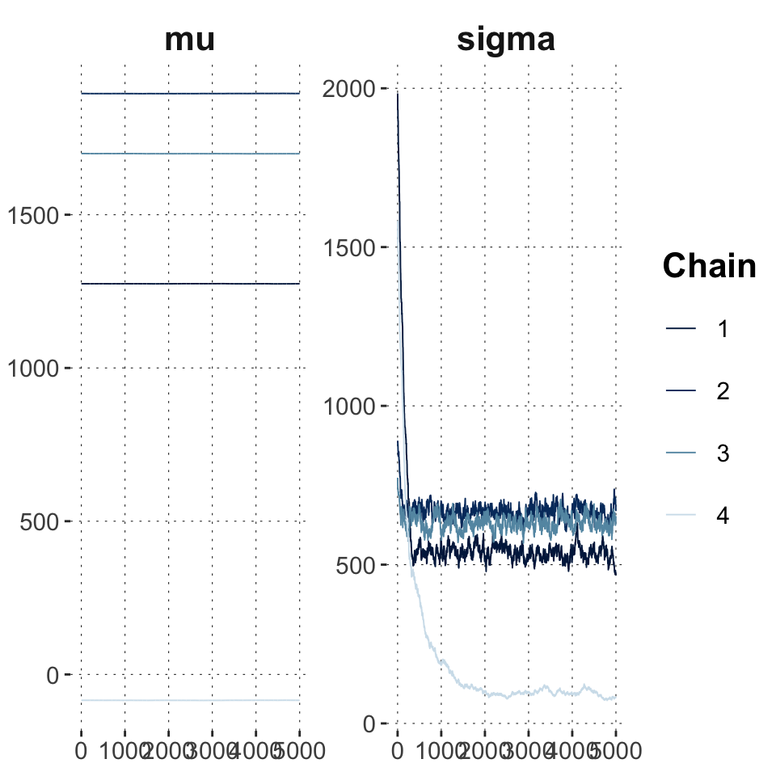

```r
bayesplot::mcmc_trace(MH_samples_Gaussian_tiny)
```

Check $\hat{R}$:

```r
coda::gelman.diag(MH_samples_Gaussian_tiny)
```

```
## Potential scale reduction factors:
##
##       Point est. Upper C.I.
## mu        7427.0    13949.2
## sigma       17.6       33.2
##
## Multivariate psrf
##
## 6656
```

## Exercise 2c [SELF-PRACTICE]: Far-off initialization and large steps

Like in the previous messed-up version, the MH instance below initializes parameters randomly but somewhere likely to be far outside the “typical set”. But now it also uses a large range for likely proposals. Inspect the code below (see the places where the comments say “CHANGED”) and try to understand *what* has changed. Then try to predict what will happen to the MCMC samples before actually running the code.

```r
MH_Gaussian_faroff_large <- function(iterations = 50, chains = 2, warmup = 0){
  # prepare 'container' to store the output
  out <- array(0, dim = c(chains, iterations - warmup, 2))
  dimnames(out) <- list("chain" = 1:chains,
                       "iteration" = 1:(iterations-warmup),
                       "variable" = c("mu", "sigma"))
  # iterate over chains
  for (c in 1:chains){
    # sample initial parameters at random far outside the expected "typical set"
    mu    <- rnorm(1, mean = 1000, sd = 500)
    sigma <- abs(rnorm(1, mean = 1000, sd = 500))
    # iterate MCMC steps
    for (i in 1:iterations){
      # CHANGED: rather large proposal ranges
      mu_next    <- rnorm(1, mean = mu, sd = 50)
      d <- 5
      sigma_next <- rlnorm(1, mean = log(sigma) - 0.5*d^2, sdlog = d)
      # calculate the accept rate (correcting for asymetric proposals for sigma)
      accept_prob <- min(
        exp(
          target_f(mu_next, sigma_next) -
            target_f(mu, sigma) +
            dlnorm(sigma, mean = log(sigma_next) - 0.5*d^2, sdlog = d, log = T) -
            dlnorm(sigma_next, mean = log(sigma) - 0.5*d^2, sdlog = d, log = T)
        ),
        1
      )
      # test the accept rate
      if (rbernoulli(1, p = accept_prob)) {
        mu    <- mu_next
        sigma <- sigma_next
      }
      # record sample (only after warmup)
      if (i >= warmup){
        out[c,i-warmup,1] <- mu
        out[c,i-warmup,2] <- sigma
      }
    }
  }
  # return samples as an 'mcmc.list' object (from the 'coda' package)
  return(coda::mcmc.list(map(1:chains, function(c) coda::mcmc(out[c,,]))))
}
```

## Exercise 2d [SELF-PRACTICE]: Sample and inspect

Now collect 5,000 samples from four chains each, without any warmup.

```r
MH_samples_Gaussian_large <- MH_Gaussian_faroff_large(
  iterations = 5000,
  chains = 4,
  warmup = 0
)
```

Look at the traceplots for the parameters.

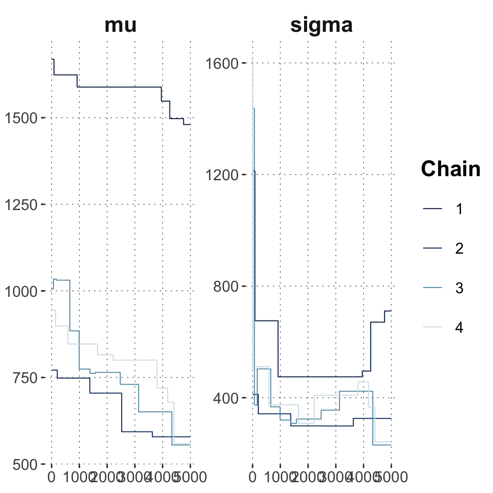

```r
bayesplot::mcmc_trace(MH_samples_Gaussian_large)
```

Check $\hat{R}$:

```r
coda::gelman.diag(MH_samples_Gaussian_large)
```

```
## Potential scale reduction factors:
##
##       Point est. Upper C.I.
## mu          9.98      23.79
## sigma       2.08       3.68
##
## Multivariate psrf
##
## 9.02
```

# Exercise 3 [HOMEWORK]: Compare efficiency to a much better sampler

Let’s use `brms` to obtain samples from the Gaussian model for the flower data in order to learn two things:

1. How to see that the “single Gaussian” model is a special case of linear regression.
2. To see how much more efficient the sampler is that `brms` relies on.

## Exercise 3a [HOMEWORK]: Intercept-only model

Consider $N$ metric measurements in vector $\vec{y}$ and a regression model for the data in $\vec{y}$ which contains only an intercept parameter. Write down the likelihood function for this regression model and argue (informally, in one short sentence) that this model is equivalent to a single Gaussian model (of the kind we analyzed above).

**Answer:** The likelihood of the constant model is defined by $LH = mean(\vec{y})$. The model is equivalent to the model above, because the constant model is essentially just the mean of the data points, which is the same for the model of the normal distribution.

## Exercise 3b [HOMEWORK]: Running the intercept-only model with `brms`

Run the following code to obtain samples from the intercept-only model in `brms`. Notice the formula syntax `heights_A ~ 1` where we specify the intercept with the number 1. Notice also that we can set parameters about the MCMC sampling process in the call to `brm`, specifying the number of chains, the samples to obtain and the warmup.

```r
HMC_samples_Gaussian <- brm(
  formula = heights_A ~ 1,
  data = tibble(heights_A),
  chains = 4,
  iter = 20000,
  warmup = 5000
)
```

Use the function `plot` to produce a traceplot from the `brms-fit` object `HMC_samples_Gaussian`. Interpret what you see, in particular say whether the picture suggests convergence.

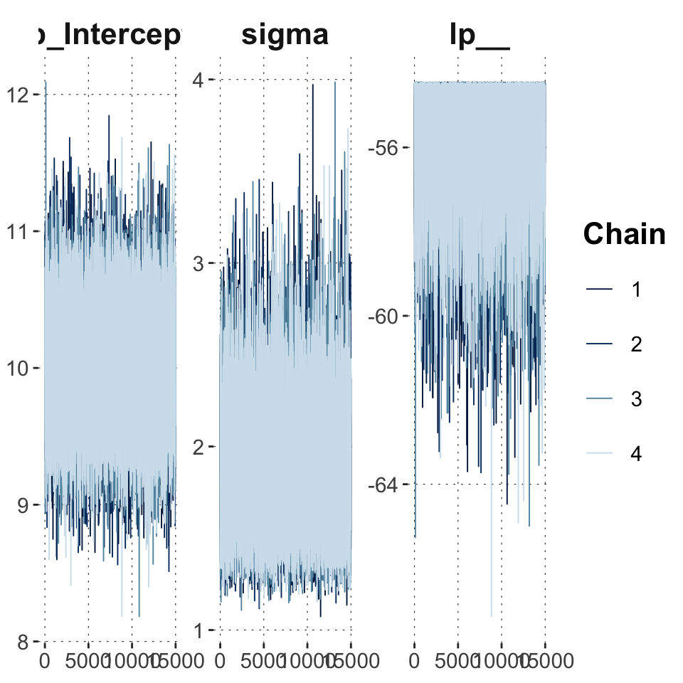

```r
# plot(HMC_samples_Gaussian)
bayesplot::mcmc_trace(HMC_samples_Gaussian)
```

**Answer:** The trace plot suggests convergence, as the chains are fairly intertwined.

Use `summary` to obtain more information about the `brms-fit` object `HMC_samples_Gaussian`. Find information on the efficient sample size for these samples and comment on the direct comparison with the hand-made MH-algorithm.

```r
summary(HMC_samples_Gaussian)
```

```
##  Family: gaussian
##   Links: mu = identity; sigma = identity
## Formula: heights_A ~ 1
##    Data: tibble(heights_A) (Number of observations: 25)
## Samples: 4 chains, each with iter = 20000; warmup = 5000; thin = 1;
##          total post-warmup samples = 60000
##
## Population-Level Effects:
##           Estimate Est.Error l-95% CI u-95% CI Rhat Bulk_ESS Tail_ESS
## Intercept    10.03      0.37     9.29    10.77 1.00    43440    36629
##
## Family Specific Parameters:
##       Estimate Est.Error l-95% CI u-95% CI Rhat Bulk_ESS Tail_ESS
## sigma     1.86      0.29     1.39     2.52 1.00    42847    34892
##
## Samples were drawn using sampling(NUTS). For each parameter, Bulk_ESS
## and Tail_ESS are effective sample size measures, and Rhat is the potential
## scale reduction factor on split chains (at convergence, Rhat = 1).
```

```r
coda::effectiveSize(HMC_samples_Gaussian)
```

```
## b_Intercept       sigma        lp__
##    43173.27    40998.57    25037.05
```

```r
coda::effectiveSize(MH_samples_Gaussian)
```

```
##       mu    sigma
## 2630.238 3431.002
```

**Answer:** The efficient sample size of the model in brms is very large in comparison, namely about 40000 samples, while the effective samples of the hand-made algorithm lies just around 2600. Thus, our model is way more effective in brms.

# Exercise 4 [HOMEWORK]: A hand-coded MH-sampler for a regression model

To apply our knowledge of the mechanics of an MH-sampler, let’s apply it to our running example of a linear regression of Area-Under-Curve predicted by Maximum-Absolute-Deviation for the mouse-tracking data. Here’s the data we’d like to use (as before):

```r
# pick up data set
dolphin <- aida::aidata

# aggregate (as before)
dolphin_agg <- dolphin %>%
  filter(correct == 1) %>%
  group_by(subject_id) %>%
  dplyr::summarize(AUC = median(AUC, na.rm = TRUE),
            MAD = median(MAD, na.rm = TRUE))

# to-be-explained variable y
y <- dolphin_agg$AUC

# explanatory variables x
x <- dolphin_agg$MAD

# number of observations
N <- length(y)
```

## Exercise 4a [HOMEWORK]: Fix the target function

As in the previous case of a Gaussian model, we first define the “target function”, the logarithm of non-normalized posteriors. The code below contains four occurrences of `XXX` where you should fill in the required code to make this work.

```r
# target function to approximate:
#   log of non-normalized posterior: prior times likelihood
target_f <- function(beta_0, beta_1, sigma){
  # sigma cannot be negative
  if (sigma <=0){
    return(-Inf)
  }
  # prior over coefficients: normal distributions
  prior_beta_0 <- dnorm(beta_0, mean = 0, sd = 10000, log = T)
  prior_beta_1 <- dnorm(beta_1, mean = 0, sd = 10000, log = T)
  # prior over sigma: (truncated) normal distribution (informed by data)
  prior_sigma  <- dnorm(sigma, mean = 15000, sd = 10000, log = T)
  likelihood   <-  sum(map_dbl(1:N, function(i) {dnorm(x = y[i], mean = beta_0 + beta_1 * x[i], sd = sigma, log = T)}))
  return(prior_beta_0 + prior_beta_1 + prior_sigma + likelihood)
}
```

## Exercise 4b [HOMEWORK]: Fix the MH-sampler

Here is a version of the MH-sampler with some of the most important parameters that influence sampling success pulled out and initialized very badly. Find values for these parameters such that $\hat{R}$ is below 1.1 for all parameters (or as close to 1.1 as you can get it). Do this for samples of 15,000 iterations per chain (after warm-up), with four chains and a warm-up of 5,000.

**Hints:** Notice that one sampling round takes quite some time. That’s why you really want to understand what changing different parameters will do to the chains. Inspect the traceplots to see what may have gone wrong. Try out a few parameter values, then think. Trial-and-error without understanding is not efficient here.

```r
initial_mean_beta_0 <- 500
initial_mean_beta_1 <- 100

initial_SD_beta_0 <- 20
initial_SD_beta_1 <- 70

proposal_SD_beta_0 <- 500
proposal_SD_beta_1 <- 10

MH_regression <- function(iterations = 50, chains = 2, warmup = 0){
  # prepare 'container' to store the output
  out <- array(0, dim = c(chains, iterations - warmup, 3))
  dimnames(out) <- list("chain" = 1:chains,
                       "iteration" = 1:(iterations-warmup),
                       "variable" = c("beta_0", "beta_1", "sigma"))
  # iterate over chains
  for (c in 1:chains){
    # sample initial parameters in a way that is informed by the data (to ease inference)
    beta_0 <- rnorm(1, mean = initial_mean_beta_0, sd = initial_SD_beta_0)
    beta_1 <- rnorm(1, mean = initial_mean_beta_1, sd = initial_SD_beta_1)
    sigma  <- rnorm(1, mean = 15000, sd = 2000)
    # iterate MCMC steps
    for (i in 1:iterations){
      # generate proposal for next parameter pair
      beta_0_next <- rnorm(1, mean = beta_0, sd = proposal_SD_beta_0)
      beta_1_next <- rnorm(1, mean = beta_1, sd = proposal_SD_beta_1)
      d <- 1
      sigma_next <- rlnorm(1, mean = log(sigma) - 0.5*d^2, sdlog = d)
      # calculate the accept rate (correcting for asymetric proposals for sigma)
      accept_prob <- min(
        exp(
          target_f(beta_0_next, beta_1_next, sigma_next) -
            target_f(beta_0, beta_1, sigma) +
            dlnorm(sigma, mean = log(sigma_next) - 0.5*d^2, sdlog = d, log = T) -
            dlnorm(sigma_next, mean = log(sigma) - 0.5*d^2, sdlog = d, log = T)
        ),
        1
      )
      # check wether to accept the proposal & update
      if (rbernoulli(1, p = accept_prob)) {
        beta_0 <- beta_0_next
        beta_1 <- beta_1_next
        sigma  <- sigma_next
      }
      # record sample (only after warmup)
      if (i >= warmup){
        out[c,i-warmup,1] <- beta_0
        out[c,i-warmup,2] <- beta_1
        out[c,i-warmup,3] <- sigma
      }
    }
  }
  # return samples as an 'mcmc.list' object (from the 'coda' package)
  return(coda::mcmc.list(map(1:chains, function(c) coda::mcmc(out[c,,]))))
}
```

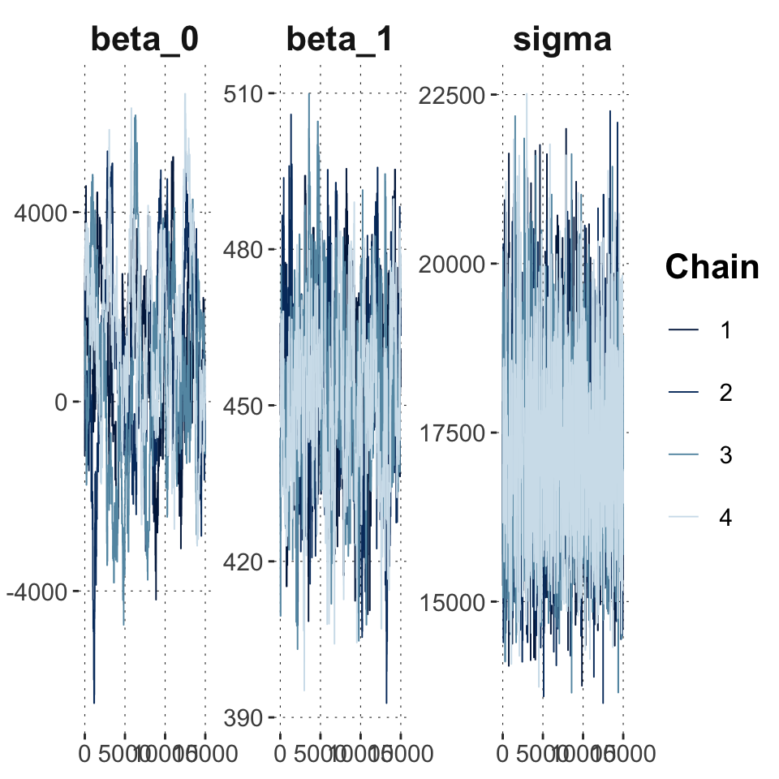

```r
MH_samples_regression <- MH_regression(
  iterations = 20000,
  chains = 4,
  warmup = 5000
)

bayesplot::mcmc_trace(MH_samples_regression)
```

```r
coda::gelman.diag(MH_samples_regression)
```

```
## Potential scale reduction factors:
##
##        Point est. Upper C.I.
## beta_0       1.06       1.17
## beta_1       1.06       1.16
## sigma        1.00       1.00
##
## Multivariate psrf
##
## 1.07
```

```r
print(summary(MH_samples_regression), digits = 6)
```

```
##
## Iterations = 1:15000
## Thinning interval = 1
## Number of chains = 4
## Sample size per chain = 15000
##
## 1. Empirical mean and standard deviation for each variable,
##    plus standard error of the mean:
##
##             Mean        SD  Naive SE Time-series SE
## beta_0   911.069 1919.8849 7.8378973     231.458465
## beta_1   453.286   16.4552 0.0671782       0.943029
## sigma  17169.255 1212.4877 4.9499603      23.599799
##
## 2. Quantiles for each variable:
##
##            2.5%       25%       50%       75%     97.5%
## beta_0 -2803.38  -384.236   879.241  2250.685  4658.646
## beta_1   420.37   442.775   453.378   463.973   485.974
## sigma  15045.49 16313.258 17073.062 17911.999 19787.337
```

## Exercise 4c [HOMEWORK]: Plot the posterior samples

Make a scatter plot of the samples, with samples for $\beta_0$ on the $x$-axis and samples for $\beta_1$ on the $y$-axis. Comment on whether, given model and data, belief in the proposition that the slope is positive seems warranted.

```r
MH_samples_regression_tidy <- ggmcmc::ggs(MH_samples_regression)
head(MH_samples_regression_tidy)
```

```
## # A tibble: 6 x 4
##   Iteration Chain Parameter  value
##       <int> <int> <fct>      <dbl>
## 1         1     1 beta_0    -1148.
## 2         2     1 beta_0    -1148.
## 3         3     1 beta_0     -454.
## 4         4     1 beta_0     -454.
## 5         5     1 beta_0     -454.
## 6         6     1 beta_0     -454.
```

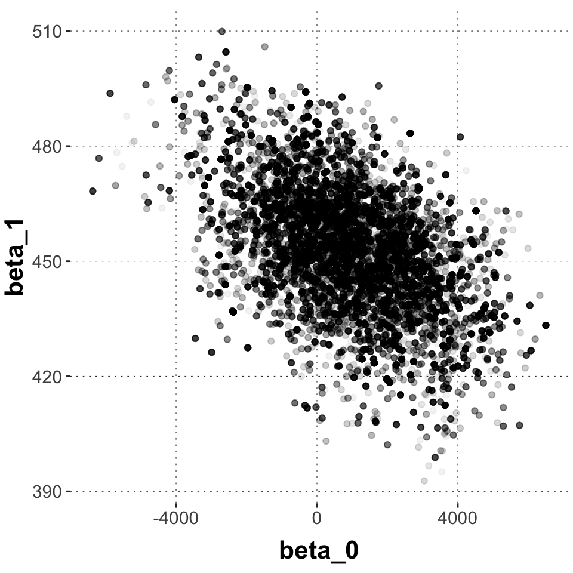

```r
MH_samples_regression_tidy <-
  MH_samples_regression_tidy %>%
  pivot_wider(names_from = Parameter, values_from = value)

MH_samples_regression_tidy %>%
  ggplot(aes(x = beta_0, y = beta_1)) +
  geom_point(alpha = 0.05) +
  theme_aida()
```

**Answer:** Given our MH model, which seems to suggest convergence since the chains are indifferentiable intertwined, and our data we could conclude that it is reasonable to propose a positive slope (beta_1) of the regression as its mean lies around 450.

# Exercise 5 [BONUS]: A hand-coded Gibbs sampler for binomial data

Suppose we know that a coin was flipped $N = 50$ times. We do not know the coin’s bias $\theta$, but hold the following prior beliefs: $\theta \sim \text{Beta}(5, 10)$. We also do not know the number $k$ of observed successes, but believe that any number $0, \dots, 50$ is equally likely.

We are interested in the joint posterior distribution $P(\theta, k \mid N)$. Write your own hand-crafted Gibbs sampler to obtain samples from this joint posterior distribution. Set the initial values of $\theta$ and $k$ for each chain to random samples for the priors. Collect 5,000 samples from each of four chains (20,000 samples in total) after a burn-in of 2,000 with no thinning and visualize the results in a scatter plot. Check model convergence using $\hat{R}$ and determine the efficient sample size.

Notice that the conditional posteriors for each parameter of relevance are:

$$\begin{aligned}
k \mid \theta, N & \sim \text{Binom}(\theta, N)\\
\theta \mid k, N & \sim \text{Beta}(5 + k , 10 + N - k)
\end{aligned}$$

```r
# your solution here
```